# Block 5 - Own Research Question

## Periods

Central Europe had an exceptional drought from 2018 to 2020. Tree mortality usually shows up with a delay, so the period **up to and including 2020** is compared with the period **after the drought**. 2020 is put in the first period only, so that no year is counted twice.

```r
before_end <- 2020   # last year of the first period -- change here if needed

dt <- dt |>
  mutate(period = if_else(year <= before_end,
                          paste0("2017–", before_end),
                          paste0(before_end + 1, "–2025")),
         period = factor(period, levels = c(paste0("2017–", before_end),
                                            paste0(before_end + 1, "–2025"))))

dt |> count(site_id, period) |> kable()
```

| site_id | period | n |
| --- | --- | --- |
| DE-GsB | 2017–2020 | 4 |
| DE-GsB | 2021–2025 | 5 |
| FR-EM2 | 2017–2020 | 4 |
| FR-EM2 | 2021–2025 | 5 |

## Deadwood cover over time

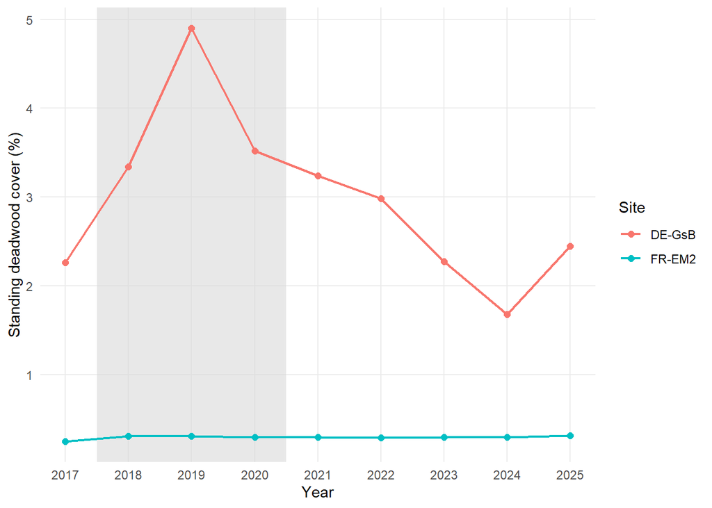

Figure 2: Yearly standing deadwood cover around each tower. The grey band marks the 2018–2020 drought.

```r
ggplot(dt, aes(x = year, y = deadwood_pct, colour = site_id)) +
  annotate("rect", xmin = 2017.5, xmax = 2020.5, ymin = -Inf, ymax = Inf,
           fill = "grey85", alpha = 0.6) +
  geom_line(linewidth = 0.8) +
  geom_point(size = 2) +
  scale_x_continuous(breaks = 2017:2025) +
  labs(x = "Year", y = "Standing deadwood cover (%)", colour = "Site") +
  theme_minimal() +
  theme(panel.grid.minor = element_blank())
```

## Comparison of the two periods

```r
period_means <- dt |>
  group_by(site_id, period) |>
  summarise(mean_deadwood = mean(deadwood_pct, na.rm = TRUE), .groups = "drop")

change <- period_means |>
  pivot_wider(names_from = period, values_from = mean_deadwood) |>
  mutate(`Change (pp)` = .data[[levels(dt$period)[2]]] - .data[[levels(dt$period)[1]]],
         `Change (%)`  = 100 * `Change (pp)` / .data[[levels(dt$period)[1]]])

kable(change, digits = 2,
      col.names = c("Site", paste("Mean", levels(dt$period), "(%)"),
                    "Change (percentage points)", "Relative change (%)"))
```

Table 1: Mean standing deadwood cover per period and the change between them.

| Site | Mean 2017–2020 (%) | Mean 2021–2025 (%) | Change (percentage points) | Relative change (%) |
| --- | --- | --- | --- | --- |
| DE-GsB | 3.51 | 2.52 | -0.98 | -28.03 |
| FR-EM2 | 0.29 | 0.30 | 0.01 | 2.62 |

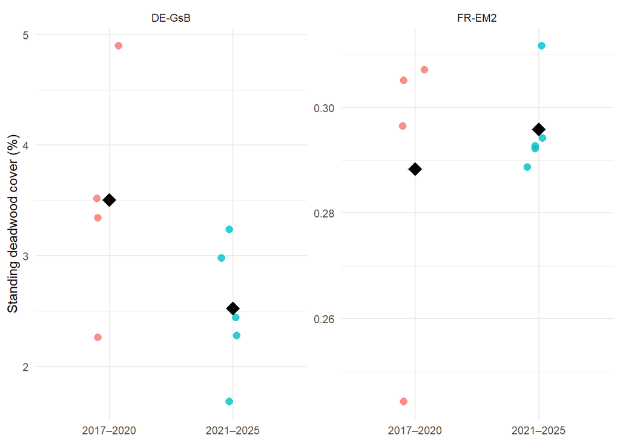

Figure 3: Standing deadwood cover per year, grouped by period. Points are single years, the black diamond is the period mean.

```r
ggplot(dt, aes(x = period, y = deadwood_pct, colour = period)) +
  geom_jitter(width = 0.1, size = 2.5, alpha = 0.8) +
  stat_summary(fun = mean, geom = "point", shape = 18, size = 5, colour = "black") +
  facet_wrap(~ site_id, scales = "free_y") +
  labs(x = NULL, y = "Standing deadwood cover (%)") +
  theme_minimal() +
  theme(legend.position = "none")
```

## Statistical test

A one-sided Wilcoxon rank-sum test per site checks whether deadwood cover is higher in the second period. With only 4 and 5 years per site, the test has very little power, so the result should be read together with the figures, not on its own.

```r
tests <- dt |>
  group_by(site_id) |>
  summarise(p_value = wilcox.test(deadwood_pct[period == levels(period)[2]],
                                  deadwood_pct[period == levels(period)[1]],
                                  alternative = "greater", exact = FALSE)$p.value,
            .groups = "drop")

kable(tests, digits = 3, col.names = c("Site", "p-value"))
```

Table 2: One-sided Wilcoxon rank-sum test (H1: deadwood cover higher after the drought).

| Site | p-value |
| --- | --- |
| DE-GsB | 0.944 |
| FR-EM2 | 0.730 |